# ANALISIS ESTADISTICA

Jairo Cordoba, Carol Castellanos, Samuel Medina, Paula Prado

2025-11-09

# EDAD (AGE)

```r
library(summarytools)
library(fdth)
library(readr)
DATABASE_Respuestas_de_formulario_1 <- read_csv("DATABASE - Respuestas de formulario 1.csv")
#TABLA
tabla1<-fdt(DATABASE_Respuestas_de_formulario_1$AGE,k=nclass.Sturges(DATABASE_Respuestas_de_formulario_1$AGE));tabla1
```

```
##     Class limits  f   rf rf(%)  cf cf(%)
##   [16.83,19.902) 33 0.33    33  33    33
##  [19.902,22.975) 51 0.51    51  84    84
##  [22.975,26.047) 10 0.10    10  94    94
##   [26.047,29.12)  3 0.03     3  97    97
##   [29.12,32.192)  1 0.01     1  98    98
##  [32.192,35.265)  0 0.00     0  98    98
##  [35.265,38.337)  0 0.00     0  98    98
##   [38.337,41.41)  2 0.02     2 100   100
```

```r
# MEDIDAS
library(DescTools)
Desc(DATABASE_Respuestas_de_formulario_1$AGE,plotit=FALSE,main="")
```

```
## ──────────────────────────────────────────────────────────────────────────────
##
##
##   length       n    NAs  unique     0s   mean  meanCI'
##      100     100      0      15      0  21.05   20.32
##           100.0%   0.0%           0.0%          21.78
##
##      .05     .10    .25  median    .75    .90     .95
##    17.95   18.00  19.00   20.00  22.00  25.00   27.00
##
##    range      sd  vcoef     mad    IQR   skew    kurt
##    24.00    3.69   0.18    1.48   3.00   3.00   12.12
##
## lowest : 17.0 (5), 18.0 (11), 19.0 (17), 20.0 (22), 21.0 (15)
## highest: 27.0 (2), 29.0, 30.0, 39.0, 41.0
##
## heap(?): remarkable frequency (22.0%) for the mode(s) (= 20)
##
## ' 95%-CI (classic)
```

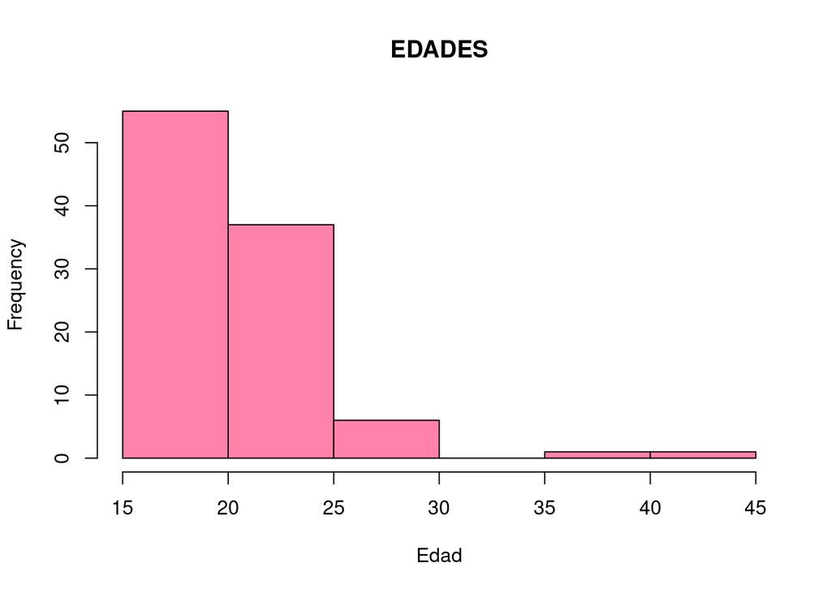

```r
#GRAFICA
#Histograma
hist(DATABASE_Respuestas_de_formulario_1$AGE,main ="EDADES",xlab="Edad",
 col= "palevioletred1")
```

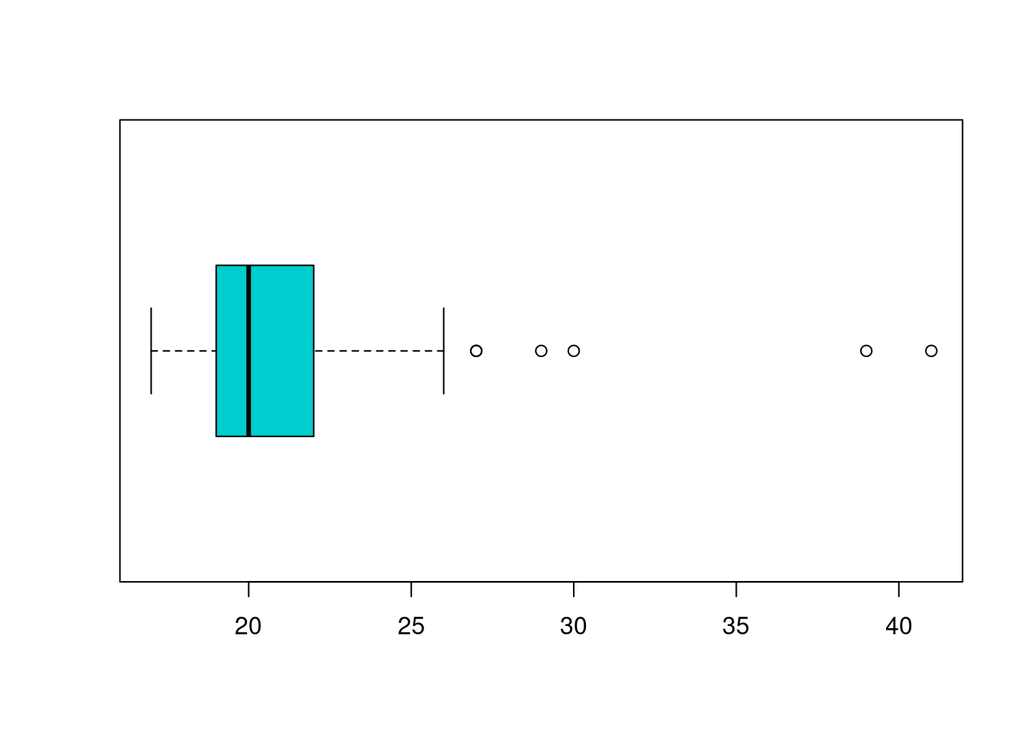

```r
 boxplot(DATABASE_Respuestas_de_formulario_1$AGE,col ="cyan3",xlab="",horizontal =T)
```

# PRESENCIA DE DISCAPACIDAD (DISC)

```r
#TABLA
freq(DATABASE_Respuestas_de_formulario_1$DISC)
```

```
## Frequencies
## DATABASE_Respuestas_de_formulario_1$DISC
## Type: Character
##
##                               Freq   % Valid   % Valid Cum.   % Total   % Total Cum.
## --------------------------- ------ --------- -------------- --------- --------------
##                          No     94     94.00          94.00     94.00          94.00
##       Prefiere no responder      4      4.00          98.00      4.00          98.00
##                          Si      2      2.00         100.00      2.00         100.00
##                        <NA>      0                               0.00         100.00
##                       Total    100    100.00         100.00    100.00         100.00
```

```r
# MEDIDAS
library(DescTools)
Desc(DATABASE_Respuestas_de_formulario_1$DISC,plotit=FALSE,main="")
```

```
## ──────────────────────────────────────────────────────────────────────────────
##
##
##   length      n    NAs unique levels  dupes
##      100    100      0      3      3      y
##          100.0%   0.0%
##
##                    level  freq   perc  cumfreq  cumperc
## 1                     No    94  94.0%       94    94.0%
## 2  Prefiere no responder     4   4.0%       98    98.0%
## 3                     Si     2   2.0%      100   100.0%
```

```r
z<-table(DATABASE_Respuestas_de_formulario_1$DISC);z
```

```
##
##                    No Prefiere no responder                    Si
##                    94                     4                     2
```

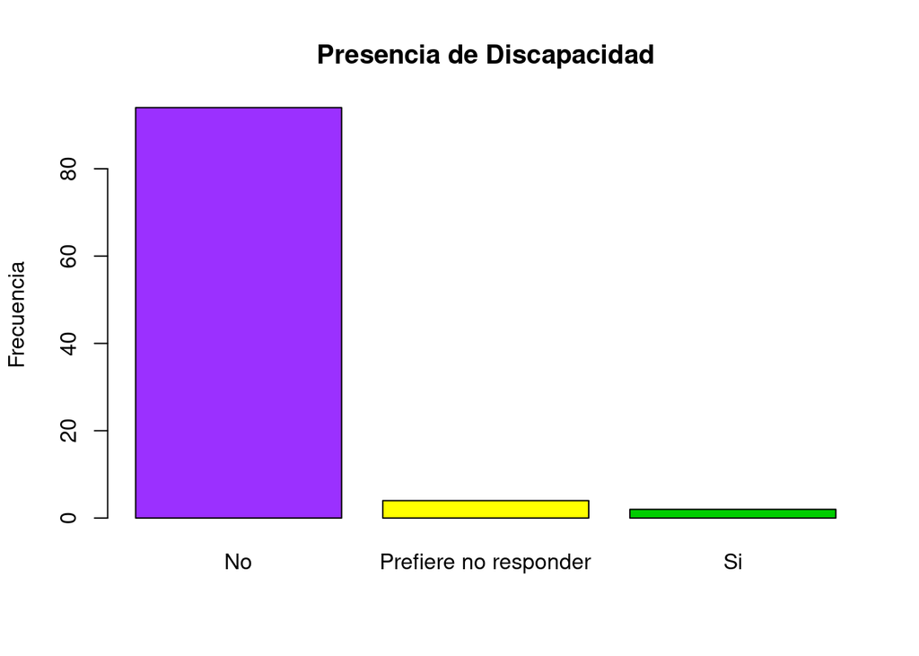

```r
# GRAFICA
#BARPLOT
barplot(height=z,col=c("purple1","yellow1","green3"),main="Presencia de Discapacidad", ylab= "Frecuencia", xlab="")
```

# HORAS DE ESTUDIO (STDH)

```r
#TABLA
freq(DATABASE_Respuestas_de_formulario_1$STDH)
```

```
## Frequencies
## DATABASE_Respuestas_de_formulario_1$STDH
## Type: Numeric
##
##               Freq   % Valid   % Valid Cum.   % Total   % Total Cum.
## ----------- ------ --------- -------------- --------- --------------
##           1     13     13.00          13.00     13.00          13.00
##           2     43     43.00          56.00     43.00          56.00
##           3     32     32.00          88.00     32.00          88.00
##           4     12     12.00         100.00     12.00         100.00
##        <NA>      0                               0.00         100.00
##       Total    100    100.00         100.00    100.00         100.00
```

```r
# MEDIDAS
library(DescTools)
Desc(DATABASE_Respuestas_de_formulario_1$STDH,plotit=FALSE,main="")
```

```
## ──────────────────────────────────────────────────────────────────────────────
##
##
##   length       n    NAs  unique    0s  mean  meanCI'
##      100     100      0       4     0  2.43    2.26
##           100.0%   0.0%          0.0%          2.60
##
##      .05     .10    .25  median   .75   .90     .95
##     1.00    1.00   2.00    2.00  3.00  4.00    4.00
##
##    range      sd  vcoef     mad   IQR  skew    kurt
##     3.00    0.87   0.36    1.48  1.00  0.17   -0.67
##
##
##    value  freq   perc  cumfreq  cumperc
## 1      1    13  13.0%       13    13.0%
## 2      2    43  43.0%       56    56.0%
## 3      3    32  32.0%       88    88.0%
## 4      4    12  12.0%      100   100.0%
##
## ' 95%-CI (classic)
```

```r
z2<-table(DATABASE_Respuestas_de_formulario_1$STDH);z
```

```
##
##                    No Prefiere no responder                    Si
##                    94                     4                     2
```

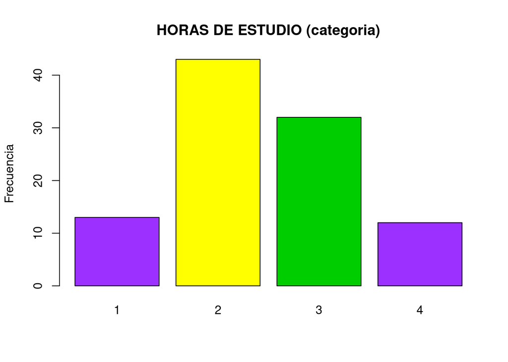

```r
# GRAFICA
#BARPLOT
barplot(height=z2,col=c("purple1","yellow1","green3"),main="HORAS DE ESTUDIO (categoria)", ylab= "Frecuencia", xlab="")
```

# LABURANTE (LAB)

```r
#TABLA
freq(DATABASE_Respuestas_de_formulario_1$LAB)
```

```
## Frequencies
## DATABASE_Respuestas_de_formulario_1$LAB
## Type: Character
##
##               Freq   % Valid   % Valid Cum.   % Total   % Total Cum.
## ----------- ------ --------- -------------- --------- --------------
##          No     58     58.00          58.00     58.00          58.00
##          Si     42     42.00         100.00     42.00         100.00
##        <NA>      0                               0.00         100.00
##       Total    100    100.00         100.00    100.00         100.00
```

```r
# MEDIDAS
library(DescTools)
Desc(DATABASE_Respuestas_de_formulario_1$LAB,plotit=FALSE,main="")
```

```
## ──────────────────────────────────────────────────────────────────────────────
##
##
##   length      n    NAs unique
##      100    100      0      2
##          100.0%   0.0%
##
##     freq   perc  lci.95  uci.95'
## No    58  58.0%   48.2%   67.2%
## Si    42  42.0%   32.8%   51.8%
##
## ' 95%-CI (Wilson)
```

```r
z3<-table(DATABASE_Respuestas_de_formulario_1$LAB);z3
```

```
##
## No Si
## 58 42
```

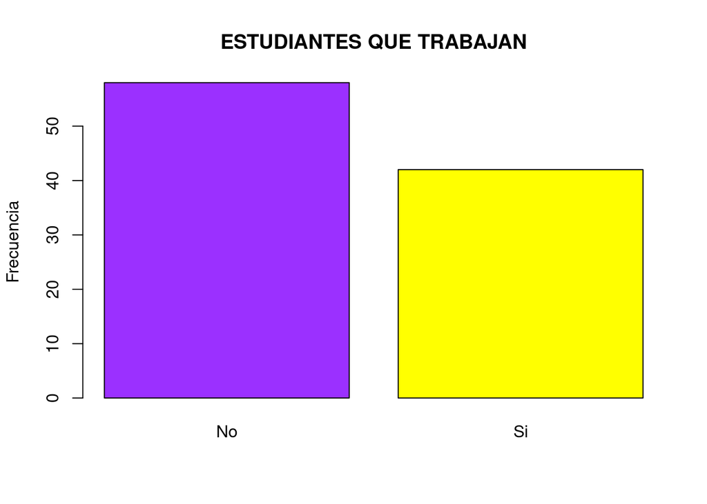

```r
# GRAFICA
#BARPLOT
barplot(height=z3,col=c("purple1","yellow1","green3"),main="ESTUDIANTES QUE TRABAJAN", ylab= "Frecuencia", xlab="")
```

# PROMEDIO ACADEMICO (PM)

```r
#TABLA
tabla1<-fdt(DATABASE_Respuestas_de_formulario_1$PM,k=nclass.Sturges(DATABASE_Respuestas_de_formulario_1$PM));tabla1
```

```
##       Class limits  f   rf rf(%)  cf cf(%)
##      [297,314.541)  7 0.07     7   7     7
##  [314.541,332.082) 12 0.12    12  19    19
##  [332.082,349.624) 20 0.20    20  39    39
##  [349.624,367.165) 29 0.29    29  68    68
##  [367.165,384.706) 20 0.20    20  88    88
##  [384.706,402.248)  9 0.09     9  97    97
##  [402.248,419.789)  2 0.02     2  99    99
##   [419.789,437.33)  1 0.01     1 100   100
```

```r
# MEDIDAS
library(DescTools)
Desc(DATABASE_Respuestas_de_formulario_1$PM,plotit=FALSE,main="")
```

```
## ──────────────────────────────────────────────────────────────────────────────
##
##
##   length       n     NAs  unique      0s    mean  meanCI'
##      100     100       0      58       0  356.24  351.22
##           100.0%    0.0%            0.0%          361.26
##
##      .05     .10     .25  median     .75     .90     .95
##   313.95  325.90  339.50  355.00  374.25  385.10  400.05
##
##    range      sd   vcoef     mad     IQR    skew    kurt
##   133.00   25.28    0.07   25.20   34.75    0.22   -0.10
##
## lowest : 300.0, 306.0, 312.0 (2), 313.0, 314.0 (2)
## highest: 401.0, 402.0, 408.0, 409.0, 433.0
##
## ' 95%-CI (classic)
```

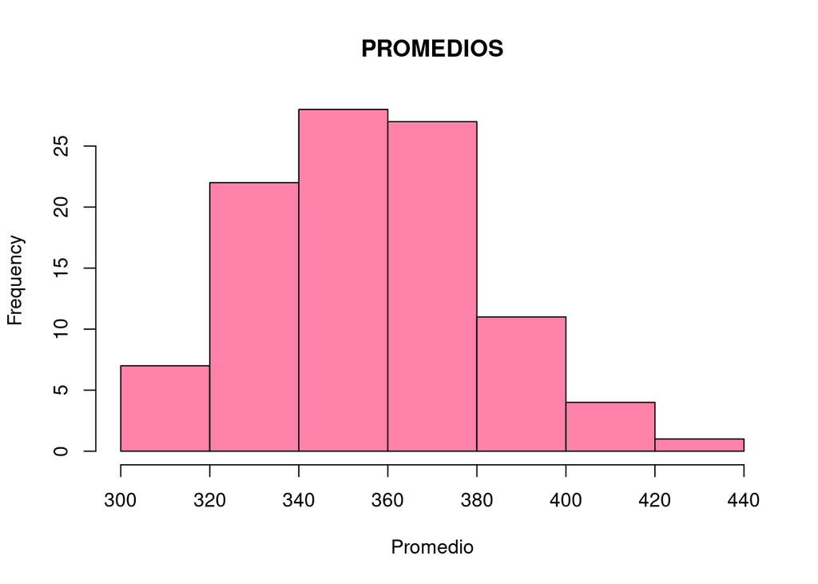

```r
#GRAFICA
#Histograma
hist(DATABASE_Respuestas_de_formulario_1$PM,main ="PROMEDIOS",xlab="Promedio",
 col= "palevioletred1")
```

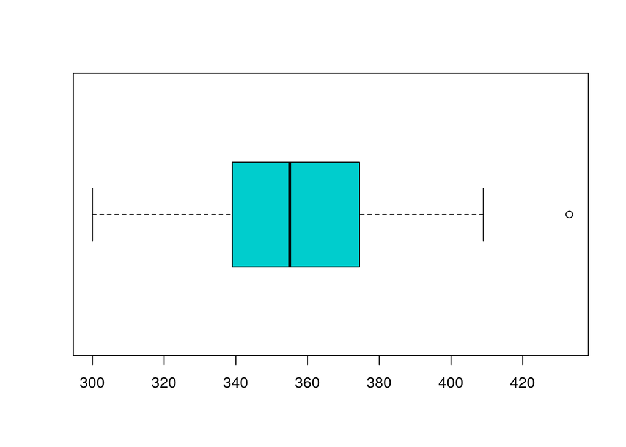

```r
 boxplot(DATABASE_Respuestas_de_formulario_1$PM,col ="cyan3",xlab="",horizontal =T)
```

# DISPONIBILIDAD DE PASATIEMPOS (PS)

```r
#TABLA
freq(DATABASE_Respuestas_de_formulario_1$PS)
```

```
## Frequencies
## DATABASE_Respuestas_de_formulario_1$PS
## Type: Character
##
##               Freq   % Valid   % Valid Cum.   % Total   % Total Cum.
## ----------- ------ --------- -------------- --------- --------------
##          No     11     11.00          11.00     11.00          11.00
##          Si     89     89.00         100.00     89.00         100.00
##        <NA>      0                               0.00         100.00
##       Total    100    100.00         100.00    100.00         100.00
```

```r
# MEDIDAS
library(DescTools)
Desc(DATABASE_Respuestas_de_formulario_1$PS,plotit=FALSE,main="")
```

```
## ──────────────────────────────────────────────────────────────────────────────
##
##
##   length      n    NAs unique
##      100    100      0      2
##          100.0%   0.0%
##
##     freq   perc  lci.95  uci.95'
## Si    89  89.0%   81.4%   93.7%
## No    11  11.0%    6.3%   18.6%
##
## ' 95%-CI (Wilson)
```

```r
z4<-table(DATABASE_Respuestas_de_formulario_1$PS);z4
```

```
##
## No Si
## 11 89
```

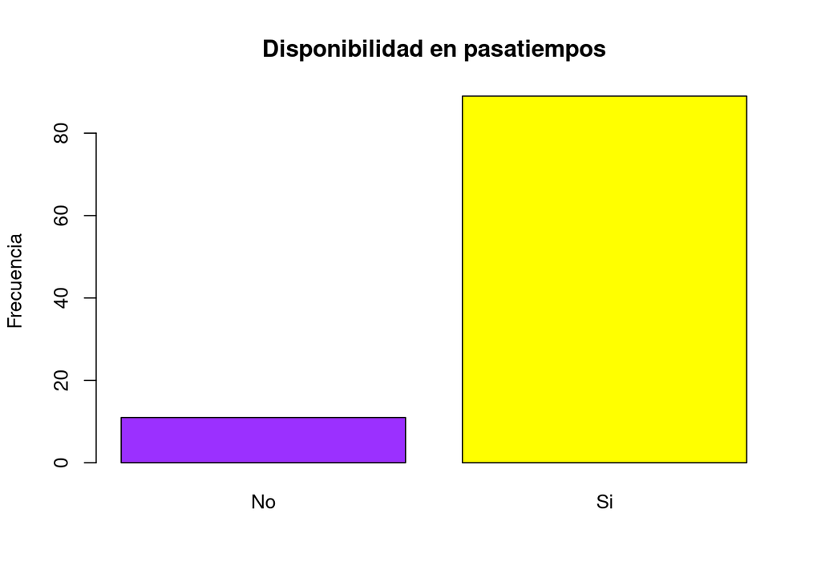

```r
# GRAFICA
#BARPLOT
barplot(height=z4,col=c("purple1","yellow1","green3"),main="Disponibilidad en pasatiempos", ylab= "Frecuencia", xlab="")
```

# SEMESTRE CON CANCELACIÓN DE MATERIAS (SC)

```r
#TABLA
tabla5<-freq(DATABASE_Respuestas_de_formulario_1$SC);tabla5
```

```
## Frequencies
## DATABASE_Respuestas_de_formulario_1$SC
## Type: Numeric
##
##               Freq   % Valid   % Valid Cum.   % Total   % Total Cum.
## ----------- ------ --------- -------------- --------- --------------
##           0     39     39.00          39.00     39.00          39.00
##           1     26     26.00          65.00     26.00          65.00
##           2     12     12.00          77.00     12.00          77.00
##           3      8      8.00          85.00      8.00          85.00
##           4      8      8.00          93.00      8.00          93.00
##           5      7      7.00         100.00      7.00         100.00
##        <NA>      0                               0.00         100.00
##       Total    100    100.00         100.00    100.00         100.00
```

```r
# MEDIDAS
library(DescTools)
Desc(DATABASE_Respuestas_de_formulario_1$SC,plotit=FALSE,main="")
```

```
## ──────────────────────────────────────────────────────────────────────────────
##
##
##   length       n    NAs  unique     0s  mean  meanCI'
##      100     100      0       6     39  1.41    1.09
##           100.0%   0.0%          39.0%          1.73
##
##      .05     .10    .25  median    .75   .90     .95
##     0.00    0.00   0.00    1.00   2.00  4.00    5.00
##
##    range      sd  vcoef     mad    IQR  skew    kurt
##     5.00    1.59   1.13    1.48   2.00  0.96   -0.29
##
##
##    value  freq   perc  cumfreq  cumperc
## 1      0    39  39.0%       39    39.0%
## 2      1    26  26.0%       65    65.0%
## 3      2    12  12.0%       77    77.0%
## 4      3     8   8.0%       85    85.0%
## 5      4     8   8.0%       93    93.0%
## 6      5     7   7.0%      100   100.0%
##
## ' 95%-CI (classic)
```

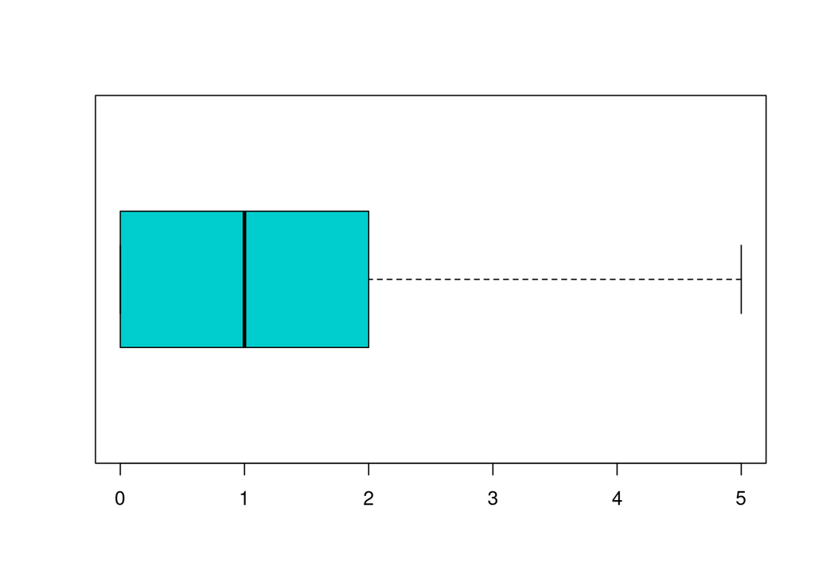

```r
#GRAFICA

 boxplot(DATABASE_Respuestas_de_formulario_1$SC,col ="cyan3",xlab="",horizontal =T)
```

# MATERIAS MATRICULADAS (MM)

```r
#TABLA
tabla5<-freq(DATABASE_Respuestas_de_formulario_1$MM);tabla5
```

```
## Frequencies
## DATABASE_Respuestas_de_formulario_1$MM
## Type: Numeric
##
##               Freq   % Valid   % Valid Cum.   % Total   % Total Cum.
## ----------- ------ --------- -------------- --------- --------------
##           1      1      1.00           1.00      1.00           1.00
##           3      2      2.00           3.00      2.00           3.00
##           4      9      9.00          12.00      9.00          12.00
##           5     42     42.00          54.00     42.00          54.00
##           6     40     40.00          94.00     40.00          94.00
##           7      6      6.00         100.00      6.00         100.00
##        <NA>      0                               0.00         100.00
##       Total    100    100.00         100.00    100.00         100.00
```

```r
# MEDIDAS
library(DescTools)
Desc(DATABASE_Respuestas_de_formulario_1$MM,plotit=FALSE,main="")
```

```
## ──────────────────────────────────────────────────────────────────────────────
##
##
##   length       n    NAs  unique    0s   mean  meanCI'
##      100     100      0       6     0   5.35    5.17
##           100.0%   0.0%          0.0%           5.53
##
##      .05     .10    .25  median   .75    .90     .95
##     4.00    4.00   5.00    5.00  6.00   6.00    7.00
##
##    range      sd  vcoef     mad   IQR   skew    kurt
##     6.00    0.93   0.17    1.48  1.00  -1.19    3.84
##
##
##    value  freq   perc  cumfreq  cumperc
## 1      1     1   1.0%        1     1.0%
## 2      3     2   2.0%        3     3.0%
## 3      4     9   9.0%       12    12.0%
## 4      5    42  42.0%       54    54.0%
## 5      6    40  40.0%       94    94.0%
## 6      7     6   6.0%      100   100.0%
##
## ' 95%-CI (classic)
```

```r
#GRAFICA
z6<-table(DATABASE_Respuestas_de_formulario_1$MM);z6
```

```
##
##  1  3  4  5  6  7
##  1  2  9 42 40  6
```

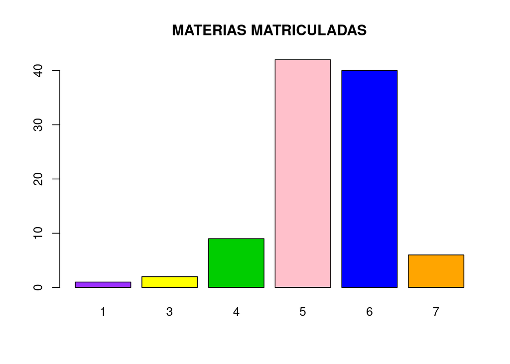

```r
barplot(height=z6,col=c("purple1","yellow1","green3","pink","blue1","orange"),main="MATERIAS MATRICULADAS",)
```

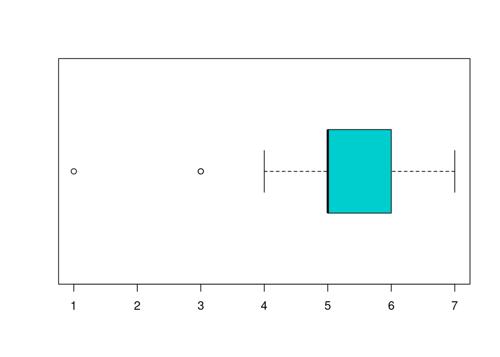

```r
boxplot(DATABASE_Respuestas_de_formulario_1$MM,col ="cyan3",xlab="",horizontal =T)
```

# SEMESTRES ACTIVO EN EL PROGRAMA (SA)

```r
#TABLA
tabla8<-freq(DATABASE_Respuestas_de_formulario_1$SA);tabla8
```

```
## Frequencies
## DATABASE_Respuestas_de_formulario_1$SA
## Type: Numeric
##
##               Freq   % Valid   % Valid Cum.   % Total   % Total Cum.
## ----------- ------ --------- -------------- --------- --------------
##           1      1      1.00           1.00      1.00           1.00
##           2     10     10.00          11.00     10.00          11.00
##           3      2      2.00          13.00      2.00          13.00
##           4     10     10.00          23.00     10.00          23.00
##           5      3      3.00          26.00      3.00          26.00
##           6     19     19.00          45.00     19.00          45.00
##           7      7      7.00          52.00      7.00          52.00
##           8     20     20.00          72.00     20.00          72.00
##           9     14     14.00          86.00     14.00          86.00
##          10      9      9.00          95.00      9.00          95.00
##          11      3      3.00          98.00      3.00          98.00
##          12      1      1.00          99.00      1.00          99.00
##          16      1      1.00         100.00      1.00         100.00
##        <NA>      0                               0.00         100.00
##       Total    100    100.00         100.00    100.00         100.00
```

```r
tabla9<-fdt(DATABASE_Respuestas_de_formulario_1$SA,k=nclass.Sturges(DATABASE_Respuestas_de_formulario_1$SA));tabla9
```

```
##     Class limits  f   rf rf(%)  cf cf(%)
##    [0.99,2.8862) 11 0.11    11  11    11
##  [2.8862,4.7825) 12 0.12    12  23    23
##  [4.7825,6.6787) 22 0.22    22  45    45
##   [6.6787,8.575) 27 0.27    27  72    72
##   [8.575,10.471) 23 0.23    23  95    95
##  [10.471,12.367)  4 0.04     4  99    99
##  [12.367,14.264)  0 0.00     0  99    99
##   [14.264,16.16)  1 0.01     1 100   100
```

```r
# MEDIDAS
library(DescTools)
Desc(DATABASE_Respuestas_de_formulario_1$SA,plotit=FALSE,main="")
```

```
## ──────────────────────────────────────────────────────────────────────────────
##
##
##   length       n    NAs  unique    0s   mean  meanCI'
##      100     100      0      13     0   6.82    6.28
##           100.0%   0.0%          0.0%           7.36
##
##      .05     .10    .25  median   .75    .90     .95
##     2.00    2.00   5.00    7.00  9.00  10.00   10.05
##
##    range      sd  vcoef     mad   IQR   skew    kurt
##    15.00    2.75   0.40    2.97  4.00  -0.04    0.10
##
## lowest : 1.0, 2.0 (10), 3.0 (2), 4.0 (10), 5.0 (3)
## highest: 9.0 (14), 10.0 (9), 11.0 (3), 12.0, 16.0
##
## heap(?): remarkable frequency (20.0%) for the mode(s) (= 8)
##
## ' 95%-CI (classic)
```

```r
#GRAFICA
z6<-table(DATABASE_Respuestas_de_formulario_1$SA);z6
```

```
##
##  1  2  3  4  5  6  7  8  9 10 11 12 16
##  1 10  2 10  3 19  7 20 14  9  3  1  1
```

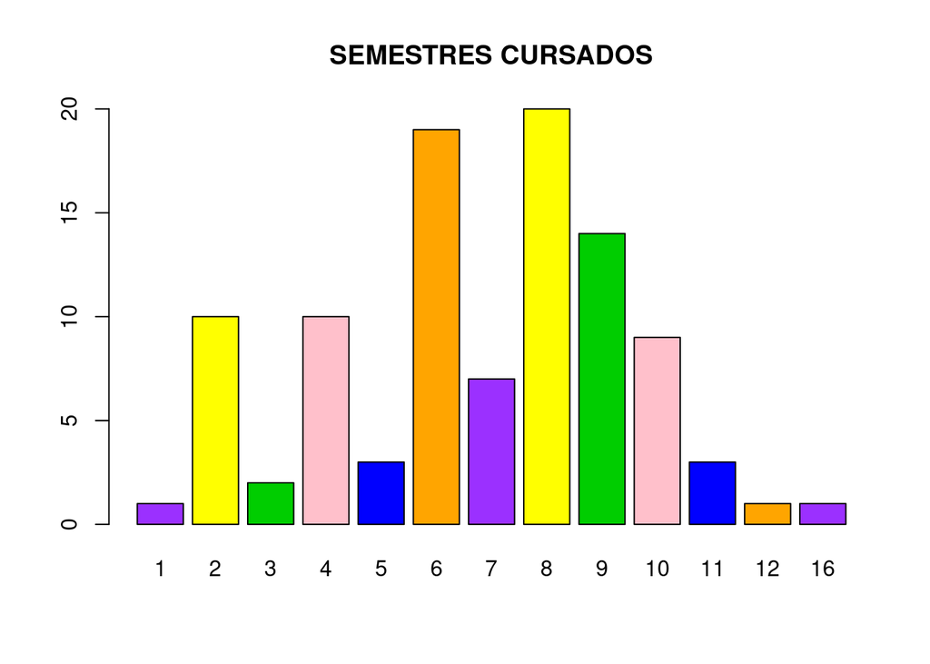

```r
barplot(height=z6,col=c("purple1","yellow1","green3","pink","blue1","orange"),main="SEMESTRES CURSADOS",)
```

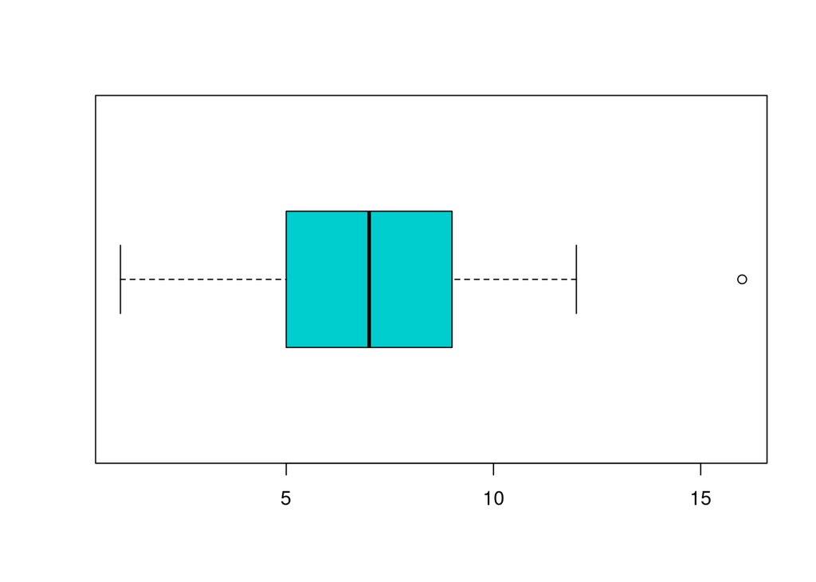

```r
boxplot(DATABASE_Respuestas_de_formulario_1$SA,col ="cyan3",xlab="",horizontal =T)
```

# NUMERO DE MATERIAS REPOBRADAS (NMR)

```r
#TABLA
tabla8<-freq(DATABASE_Respuestas_de_formulario_1$NMR);tabla8
```

```
## Frequencies
## DATABASE_Respuestas_de_formulario_1$NMR
## Type: Numeric
##
##               Freq   % Valid   % Valid Cum.   % Total   % Total Cum.
## ----------- ------ --------- -------------- --------- --------------
##           0     11     11.00          11.00     11.00          11.00
##           1     10     10.00          21.00     10.00          21.00
##           2     21     21.00          42.00     21.00          42.00
##           3     25     25.00          67.00     25.00          67.00
##           4      9      9.00          76.00      9.00          76.00
##           5      6      6.00          82.00      6.00          82.00
##           6      8      8.00          90.00      8.00          90.00
##           7      4      4.00          94.00      4.00          94.00
##           8      1      1.00          95.00      1.00          95.00
##           9      1      1.00          96.00      1.00          96.00
##          10      1      1.00          97.00      1.00          97.00
##          11      1      1.00          98.00      1.00          98.00
##          13      2      2.00         100.00      2.00         100.00
##        <NA>      0                               0.00         100.00
##       Total    100    100.00         100.00    100.00         100.00
```

```r
# MEDIDAS
library(DescTools)
Desc(DATABASE_Respuestas_de_formulario_1$NMR,plotit=FALSE,main="")
```

```
## ──────────────────────────────────────────────────────────────────────────────
##
##
##   length       n    NAs  unique     0s  mean  meanCI'
##      100     100      0      13     11  3.33    2.81
##           100.0%   0.0%          11.0%          3.85
##
##      .05     .10    .25  median    .75   .90     .95
##     0.00    0.00   2.00    3.00   4.00  6.10    8.05
##
##    range      sd  vcoef     mad    IQR  skew    kurt
##    13.00    2.64   0.79    1.48   2.00  1.43    2.59
##
## lowest : 0.0 (11), 1.0 (10), 2.0 (21), 3.0 (25), 4.0 (9)
## highest: 8.0, 9.0, 10.0, 11.0, 13.0 (2)
##
## heap(?): remarkable frequency (25.0%) for the mode(s) (= 3)
##
## ' 95%-CI (classic)
```

```r
#GRAFICA
z6<-table(DATABASE_Respuestas_de_formulario_1$NMR);z6
```

```
##
##  0  1  2  3  4  5  6  7  8  9 10 11 13
## 11 10 21 25  9  6  8  4  1  1  1  1  2
```

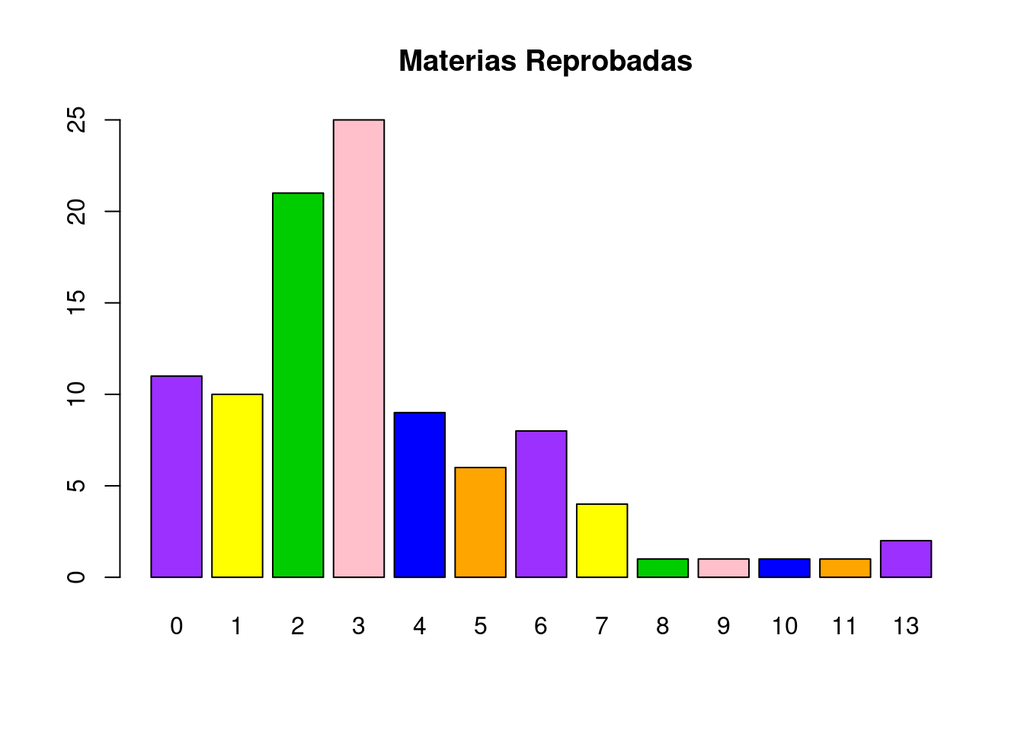

```r
barplot(height=z6,col=c("purple1","yellow1","green3","pink","blue1","orange"),main=" Materias Reprobadas",)
```

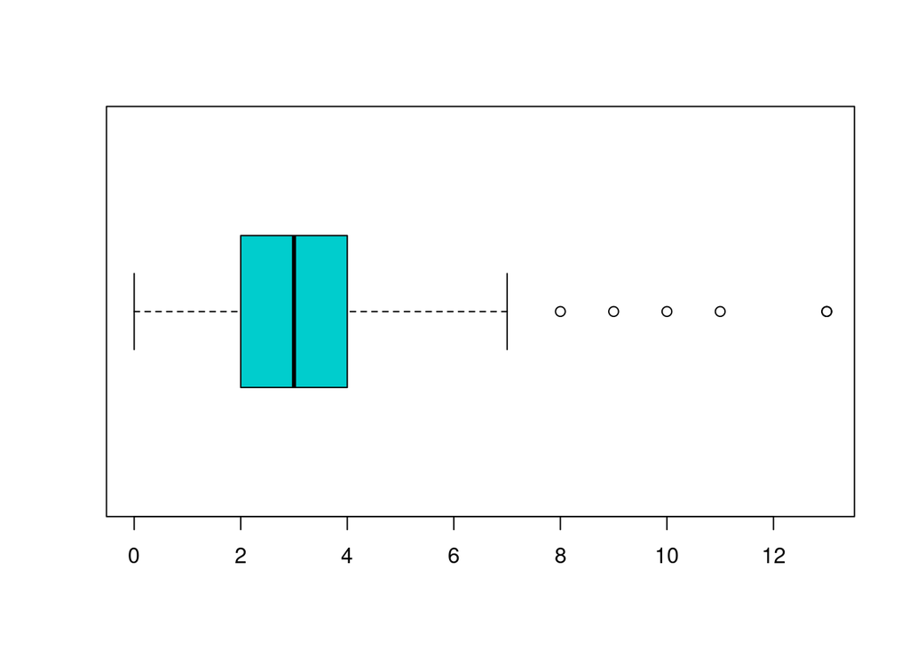

```r
boxplot(DATABASE_Respuestas_de_formulario_1$NMR,col ="cyan3",xlab="",horizontal =T)
```

# PROBABILIDADES Y CASOS INTERESANTES

## CASO I

Un caso interesante de estudio es verificar las probabilidades de que tres estudiantes estudiantes, en una muestra seleccionada tenga dos o más semestres con materias canceladas, entonces teniendo 25 estudiantes de los 100 estudiantes encuestados, tomando en cuenta que 35 estudiantes han tenido que cancelar dos o más materias, encontramos que:

Numero total de estudiantes encuestados: $N= 100$ Estudiantes seleccionados: $n=25$ Estudiantes que han cancelado dos o más materias: $k=35$

Si realizamos una distribución Binomial:

```r
prob<-1-pbinom(q=2, size=25, prob=0.35);prob
```

```
## [1] 0.9978667
```

## CASO II

Usaremos: 1. la probabilidad de que un estudiante haya reprobado materias 2. la probabilidad de que un estudiante estudie menos de 10 horas semanales

para poder calcular: la probabilidad de que un estudiante que estudia 10 o menos horas semanales repruebe materias

conocemos la probabilidad de que haya reprobado materias: $P1=0.89$ conocemos la probabilidad de que estudie 10 o menos horas: $P2=0.56$

Es decir un 49,8%